# Week1

Sarfaraz Ahmed

July 23, 2017

# Pre-Lab 1: UT Student Survey Data

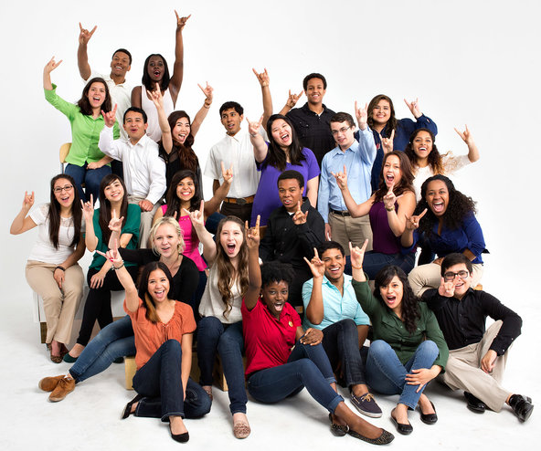

In this lab, we will examine how sample data can be used to discover the truth about a population. Our population data consists of data we collected from our statistics students here at The University of Texas at Austin. They told us several things about themselves, including how happy they are and the amount of time they study. We’ll run a few simulations on this data to see if we can replicate what the Central Limit Theorem tells us about sampling. We are pretending that we don’t know the “true” population parameters, but in fact we do!

Primary Research Question

How many letters long is the typical UT student’s name? How does our estimate change as we increase the size of our sample?

problem 3 points possible (graded) Check the Data

Let’s begin by examining our data in R.

1. Open RStudio. Make sure you’ve installed the SDSFoundations package (Version 1.4).
2. Type library(SDSFoundations). This will automatically load the data for the labs. (Note that the console may produce a warning message when this command is run. If SDS Foundations has been properly installed, this message can be ignored.) 3.Type survey <- StudentSurvey. This will assign the data to your Workspace.
3. Look at the spreadsheet view of the data to answer the following questions.

Alternatively, you can use follow the steps in the “Importing a Data Frame” R tutorial video, and use the StudentSurvey.csv file. (Right-click and “Save As.”) Make sure to name the dataframe “survey” when importing.

1. Open RStudio.
2. Click on “Import Dataset” button at the top of the workspace window. Choose “from text file.”
3. Click on the location of the StudentSurvey.csv file you just downloaded.
4. Click on the StudentSurvey.csv file. Then, click Upload.
5. Look at the spreadsheet view of the data to answer the following questions.

```r
library(SDSFoundations)

survey <- StudentSurvey
```

1a) How many students are in this dataset?

379 correct 379 1b) How many of the first 10 students in the dataset had names longer than 5 letters?

5 correct 5 1c) How long is the name of the first student in the dataset who is happy less than 40% of the time?

7 correct 7 Submit You have used 1 of 1 attempt Some problems have options such as save, reset, hints, or show answer. These options follow the Submit button.

Show Answer Correct (3/3 points) Review problem 2/2 points (graded) Check the Variables of Interest

Let’s find the variables we need to answer the question.

2a) Which variable tells us how many letters are in each student’s first name? The name of this variable in the dataset is:

name_letters correct 2b) What type of variable is this–categorical or quantitative?

quantitative correct Submit You have used 1 of 1 attempt Some problems have options such as save, reset, hints, or show answer. These options follow the Submit button.

Show Answer Correct (2/2 points) Review problem 1/2 points (graded) Reflect on the Method Which method should we be using for this analysis and why?

3a) What makes something a sampling distribution?

It is a distribution of sample statistics, such as a distribution of sample means. correct It is a distribution of all the possible values in a population. It is a distribution of all the observed values in a sample. 3b) What does the Central Limit Theorem predict about a sampling distribution of means?

The distribution looks more and more Normal as you draw larger samples. incorrect The sample means become less variable as your sample size increases. You will find the population mean at the center of the sampling distribution. All of these correct

Primary Research Question

How many letters long is the typical UT student’s name? How does our estimate change as we increase the size of our sample?

Breakdown Your Analysis

Let’s break this analysis into its required steps:

Determine the population parameters: 1. Visualize the shape of the population data by making a histogram.  
2. Calculate the “true” mean and standard deviation of the population.

Compare the sample statistics:  
3. Draw 1,000 samples of size n=5 from the population data. Calculate the mean of each sample. 4. Graph these 1,000 sample means in a histogram and examine the shape. 5. Calculate the mean and standard deviation of the sampling distribution. 6. Repeat this process for samples of size n=15 and n=25. 7. Compare the results you get to the predictions of the Central Limit Theorem.

Here is the code you will use:

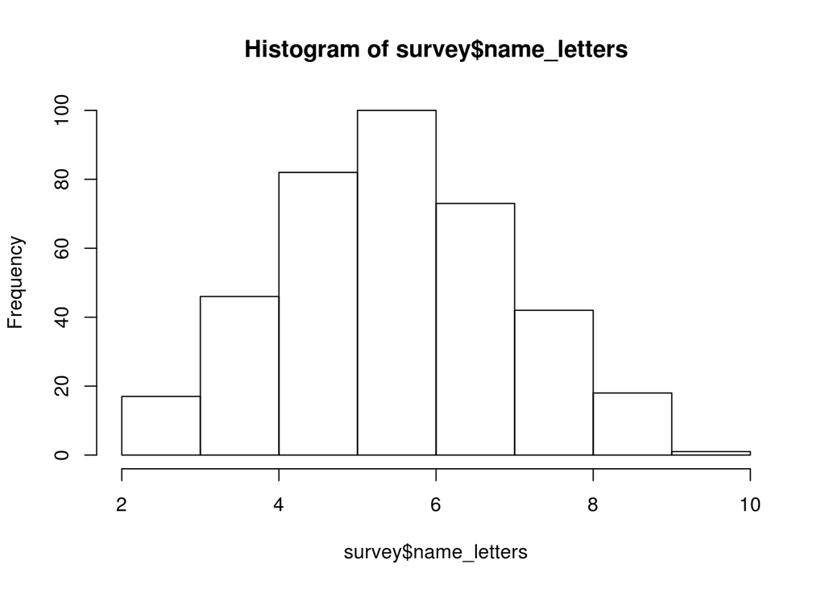

```r
# Calculate the population parameters
hist(survey$name_letters)
```

```r
fivenum(survey$name_letters)
```

```
## [1]  2  5  6  7 10
```

```r
mean(survey$name_letters)
```

```
## [1] 5.970976
```

```r
sd(survey$name_letters)
```

```
## [1] 1.49486
```

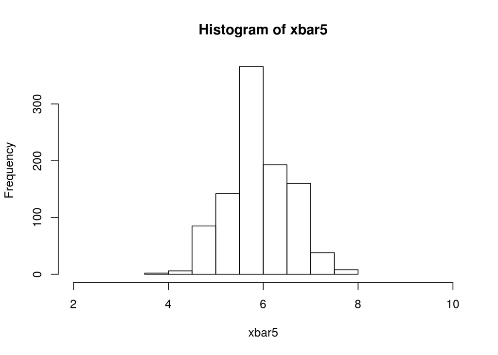

```r
# Draw 1,000 samples of n=5 and find the mean of each sample.
xbar5 <-rep(NA, 1000)
for (i in 1:1000)
{x <-sample(survey$name_letters, size =5)
xbar5[i] <-  mean(x)}


# Graph the histogram of 1,000 sample means.
hist(xbar5,xlim=c(2,10))
```

```r
# Calculate the mean and sd of the sampling distribution.
mean(xbar5)
```

```
## [1] 5.9588
```

```r
sd(xbar5)
```

```
## [1] 0.6472105
```

```r
# Compare to the std dev predicted by the CTL.
sd(survey$name_letters)/sqrt(5)
```

```
## [1] 0.6685215
```

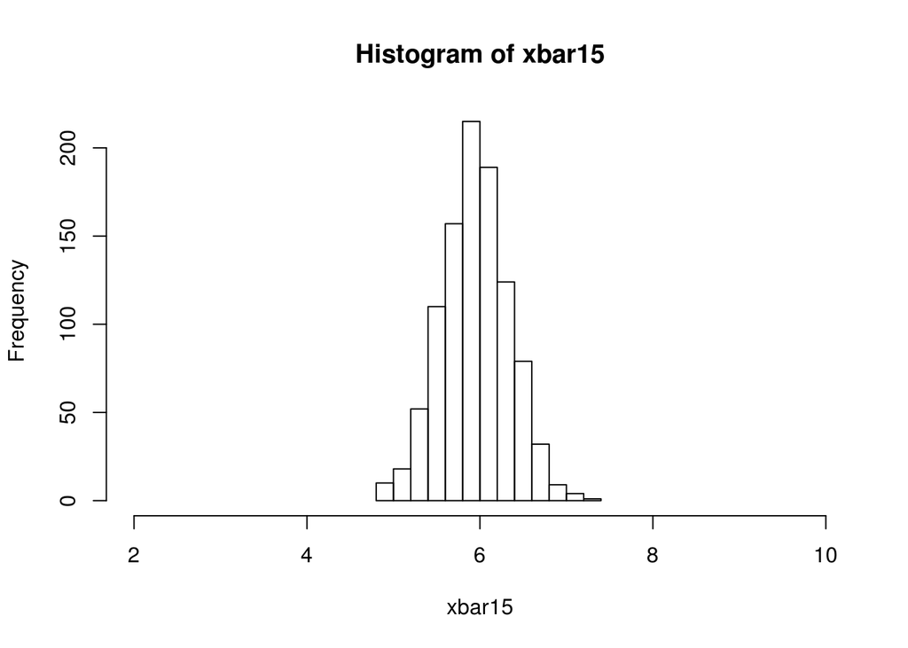

```r
#Repeat for samples of size n=15
xbar15 <-rep(NA, 1000)
for (i in 1:1000)
{x <-sample(survey$name_letters, size =15)
xbar15[i] <- mean(x)}
hist(xbar15,xlim=c(2,10))
```

```r
mean(xbar15)
```

```
## [1] 5.978333
```

```r
sd(xbar15)
```

```
## [1] 0.391475
```

```r
sd(survey$name_letters)/sqrt(15)
```

```
## [1] 0.3859711
```

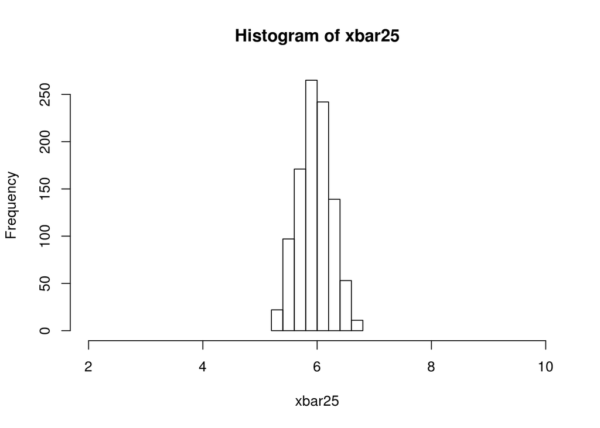

```r
#Repeat for samples of size n=25
xbar25 <-rep(NA, 1000)
for (i in 1:1000)
{x <-sample(survey$name_letters, size =25)
xbar25[i] <- mean(x)}
hist(xbar25,xlim=c(2,10))
```

```r
mean(xbar25)
```

```
## [1] 5.97892
```

```r
sd(xbar25)
```

```
## [1] 0.2875077
```

```r
sd(survey$name_letters)/sqrt(25)
```

```
## [1] 0.2989719
```

problem 3/3 points (graded) Focus on this portion of the code in order to answer the following questions:

```
xbar5<-rep(NA, 1000)
for (i in 1:1000)
{x<-sample(survey$name_letters, size =5)
xbar5[i] <- mean(x)}
```

1a) What is x?

x is the number 5 x is the number of letters in the name of one individual drawn from the population x is a sample of 5 data values drawn from the population correct 1b) What is mean(x)?

It is the mean of all the values in the population. It is the mean of the 5 data points drawn in each sample. correct It is the mean of 5 sample means. 1c) When the loop is in the 200th iteration (i=200), what will the following code be doing:

`xbar5[i] <- mean(x)`

Calculating the mean of 200 samples. Calculating the mean of the 200th sample, and placing it in the 200th position of xbar5 vector. correct Taking 200 observations from the population and then calculating the mean. Submit You have used 1 of 1 attempt Some problems have options such as save, reset, hints, or show answer. These options follow the Submit button.

Show Answer Correct (3/3 points) Review problem 1/1 point (graded) 2) The standard deviation of a sampling distribution is called a “standard error.” What goes in the denominator of this equation to solve for standard error (SE)?

`SE=σ / ?`

15 μ √n correct Submit You have used 1 of 1 attempt Some problems have options such as save, reset, hints, or show answer. These options follow the Submit button.

Show Answer Correct (1/1 point) Review problem 1/1 point (graded) 3) We used the following code to try to show the sampling distribution of ages:

```
xbar5 <-rep(NA, 1000)
for (i in 1:1000)
{x <-sample(survey$age, size =5)
xbar5[i] <- mean(x)}
hist(xbar5,xlim=c(2,10))
```

Why was the histogram that R produced blank?

The xbar5 vector (of sample means) is empty. Since we are taking random samples, it is not unusual to have this histogram. The scale of the x-axis is set from 2 to 10, but the ages are not in this range. correct The sample size in line 4 needs to be 1000 to match the previous lines.

Primary Research Question

How many letters long is the typical UT student’s name? How does our estimate change as we increase the size of our sample?

Conduct the Analysis in R

1. Type or copy the script from the the Prepare for the Analysis section into the Script window of R.
2. Select the portion of the code you wish to run, then press “ctrl+ enter.”
3. Output can be found in the Console window.

problem 2/2 points (graded) Population Parameters

1a) What is the average name length, in number of letters, for all of the students in the population? (Round to 2 decimal places.)

5.97 correct 5.97 1b) By how many letters, on average, do names vary from the mean? (Round to 2 decimal places.)

1.49 correct 1.49 Submit You have used 1 of 1 attempt Some problems have options such as save, reset, hints, or show answer. These options follow the Submit button.

Show Answer Correct (2/2 points) Review problem 2/2 points (graded) 2) In this lab, each time we sampled from our population we kept the ________ the same at 1,000, but we increased the ________ from 5 to 25. correct correct Submit You have used 1 of 1 attempt Some problems have options such as save, reset, hints, or show answer. These options follow the Submit button.

Show Answer Correct (2/2 points) Review problem 3/3 points (graded) Observing the Sampling Distributions

3a) The mean was ________ for all three sampling distributions.

correct 3b) The size of the standard error ________ as the sample size increased from 5 to 25.

correct 3c) The distributions became more and more ________ as the sample size increased.

correct Submit You have used 1 of 1 attempt Some problems have options such as save, reset, hints, or show answer. These options follow the Submit button.

Show Answer Correct (3/3 points) Review problem 4/4 points (graded) According to the Central Limit Theorem:

4a) What is the mean of the sampling distribution (for n=5, 15, or 25)? (Round to 2 decimal places)

correct 4c) What is the standard error of the sampling distribution for n=15?

correct 4d) What is the standard error of the sampling distribution for n=25?

correct Submit You have used 1 of 1 attempt Some problems have options such as save, reset, hints, or show answer. These options follow the Submit button.

Show Answer Correct (4/4 points) Review problem 1/1 point (graded) 5) Were the results of the simulations consistent with what the CLT predicted?

No Yes correct

Primary Research Question

How many letters long is the typical UT student’s name? How does our estimate change as we increase the size of our sample?

problem 11/11 points (graded) Write Your Conclusion

Answer the question and support your answer with statistics:

In this lab, we knew the average name length for our population of college students. The population mean was correct5.97 letters and the standard deviation was correct1.49 . The name lengths were correctNormally distributed .

We drew samples of different sizes from our population to simulate the Central Limit Theorem. In short, the CLT says three things:

1. As sample size increases, sampling distributions become more correctNormal .
2. The mean of the sampling distribution will be the correctpopulation mean .
3. The variability of the sample means can be predicted by dividing the population correctstandard deviation by the square root of correctthe sample size .

Our simulation results were consistent with this theory. As we increased the size of our sample from 5 to 25, the sample means become correctless variable and tended to cluster correctmore tightly around the correcttrue mean . In other words, our sample means became correctbetter estimators of the true population mean.

# Lab 1: UT Student Survey Data

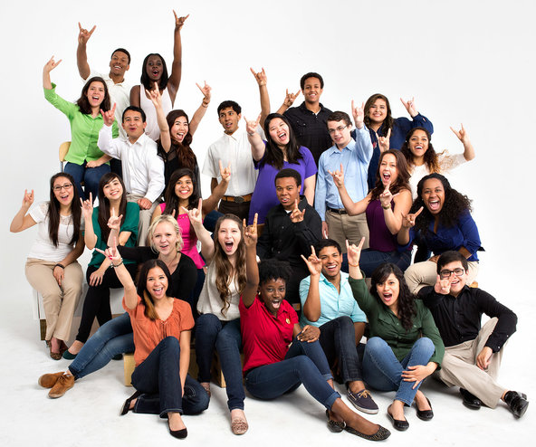

In this lab, we will examine how sample data can be used to discover the truth about a population. Our population data consists of data we collected from our statistics students here at The University of Texas at Austin. They told us several things about themselves, including how happy they are and the amount of time they study. We’ll run a few simulations on this data to see if we can replicate what the Central Limit Theorem tells us about sampling. We are pretending that we don’t know the “true” population parameters, but in fact we do!

problem 3/3 points (graded) Review of the Central Limit Theorem

In this lab, you will use a simulation to better understand the Central Limit Theorem. Let’s start by remembering the key features of the Central Limit Theorem.

1a) In this lab, we will draw samples to answer the following question: What percentage of the time are college students happy? How does the Central Limit Theorem predict our answer to this question will change as sample size increases?

As sample size increases, our sample means should become less variable and be closer to the true mean. correct Increasing sample size will have no impact on the value of our sample means. As sample size increases, the sample means we draw will all be equal to the population mean. As sample size increases, our sample means should become more variable and less accurate estimators. 1b) What does it mean to increase the sample size in a simulation?

It means to run more iterations on the data. It means to draw more individuals in each of our samples. correct It means to draw from a larger population. It means to draw more samples from our population. 1c) What should be true about our sampling distributions as we increase our sample size?

The means should decrease and the standard errors should remain about the same. The means and the standard errors should increase. The means and the standard errors should decrease. The means should remain about the same, but the standard errors should decrease. correct Submit You have used 1 of 1 attempt Some problems have options such as save, reset, hints, or show answer. These options follow the Submit button.

Show Answer Correct (3/3 points) Review Lab Preparation

In this lab you will be working with data from the UT Student Survey.

1. Open RStudio. Make sure you’ve installed the SDSFoundations package (Version 1.4).
2. Type library(SDSFoundations). This will automatically load the data for the labs. 3.Type survey <- StudentSurvey. This will assign the data to your Workspace.

Alternatively, you can use follow the steps in the “Importing a Data Frame” R tutorial video, and use the StudentSurvey.csv file. (Right-click and “Save As.”) Make sure to name the dataframe “survey” when importing.

1. Open RStudio.
2. Click on “Import Dataset” button at the top of the workspace window. Choose “from text file.”
3. Click on the location of the StudentSurvey.csv file you just downloaded.
4. Click on the StudentSurvey.csv file. Then, click Upload.

Feel free to use the script from the week’s PreLab, which you can modify for use in this Lab.

Primary Research Question

What percentage of the time are college students happy? How does our estimate of the true mean change as sample size increases?

Analysis

Let’s break this question down into the different descriptive statistics that you will need to construct your answer. Be sure that your R output includes all of the following components.

Determine the population parameters: 1. Visualize the shape of the population data by making a histogram.  
2. Calculate the “true” mean and standard deviation of the population.

Compare the sample statistics:  
3. Draw 1,000 samples of size n=5 from the population data. Calculate the mean of each sample. 4. Graph these 1,000 sample means in a histogram and examine the shape. 5. Calculate the mean and standard deviation of the sampling distribution. 6. Repeat this process for samples of size n=15 and n=25. 7. Compare the results you get to the predictions of the Central Limit Theorem.

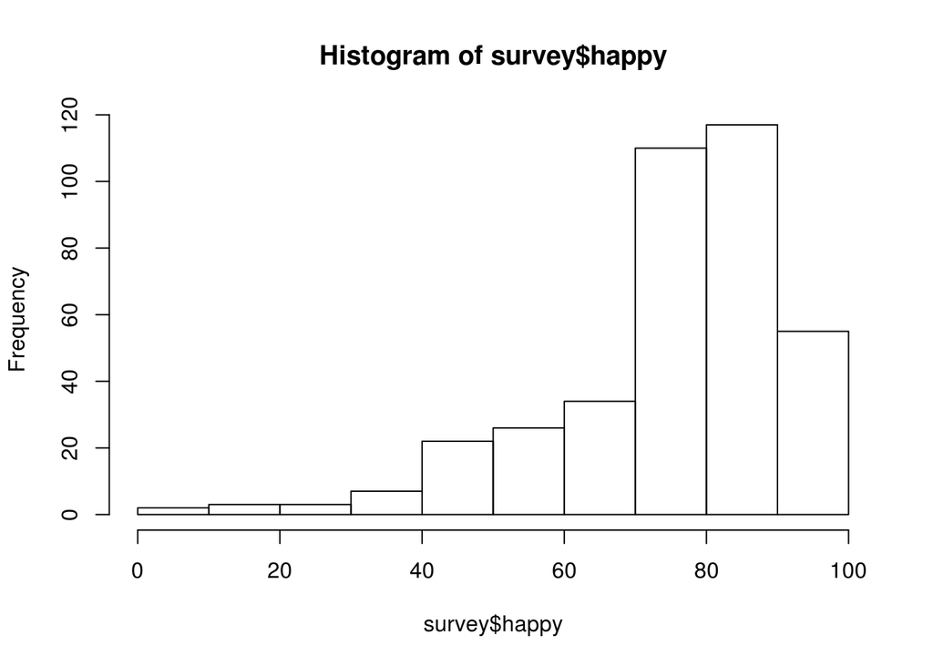

```r
# Calculate the population parameters
hist(survey$happy)
```

```r
fivenum(survey$happy)
```

```
## [1]   0  70  80  90 100
```

```r
mean(survey$happy)
```

```
## [1] 78.0343
```

```r
sd(survey$happy)
```

```
## [1] 16.30906
```

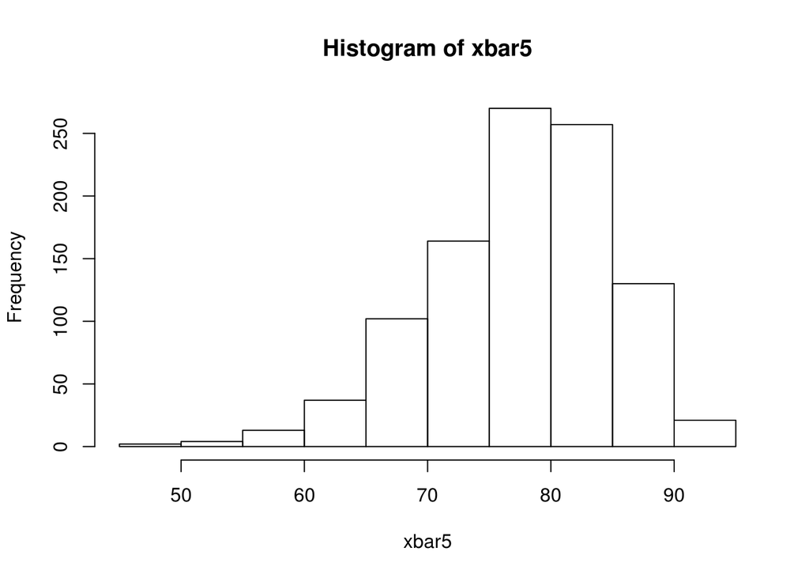

```r
# Draw 1,000 samples of n=5 and find the mean of each sample.
xbar5 <-rep(NA, 1000)
for (i in 1:1000)
{x <-sample(survey$happy, size =5)
xbar5[i] <-  mean(x)}


# Graph the histogram of 1,000 sample means.
hist(xbar5)
```

```r
# Calculate the mean and sd of the sampling distribution.
mean(xbar5)
```

```
## [1] 77.8806
```

```r
sd(xbar5)
```

```
## [1] 7.356863
```

```r
# Compare to the std dev predicted by the CTL.
sd(survey$happy)/sqrt(5)
```

```
## [1] 7.293635
```

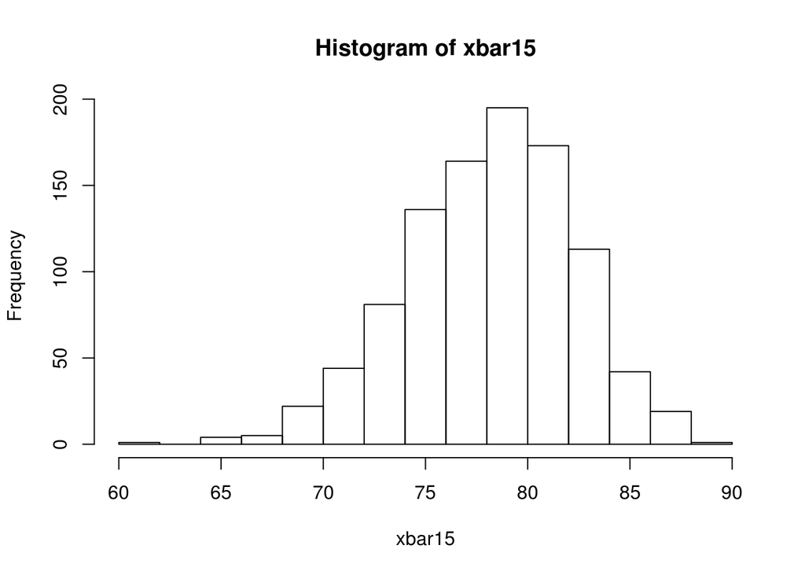

```r
#Repeat for samples of size n=15
xbar15 <-rep(NA, 1000)
for (i in 1:1000)
{x <-sample(survey$happy, size =15)
xbar15[i] <- mean(x)}
hist(xbar15)
```

```r
mean(xbar15)
```

```
## [1] 78.14047
```

```r
sd(xbar15)
```

```
## [1] 4.089508
```

```r
sd(survey$happy)/sqrt(15)
```

```
## [1] 4.210982
```

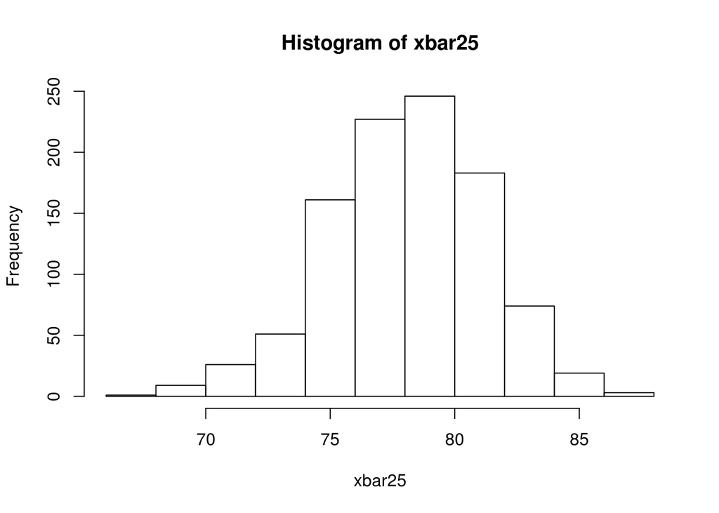

```r
#Repeat for samples of size n=25
xbar25 <-rep(NA, 1000)
for (i in 1:1000)
{x <-sample(survey$happy, size =25)
xbar25[i] <- mean(x)}
hist(xbar25)
```

```r
mean(xbar25)
```

```
## [1] 78.09912
```

```r
sd(xbar25)
```

```
## [1] 3.116317
```

```r
sd(survey$happy)/sqrt(25)
```

```
## [1] 3.261813
```

problem 3/4 points (graded) Population Parameters

1a) What is the shape of the population happiness scores?

approximately Normal positively skewed negatively skewed correct 1b) What percentage of the time are college students happy, on average? (report with no decimals and no %)

78.03 incorrect78 78.03 1c) What is the standard deviation of the happiness percent scores? (round to 1 decimal place)

16.3 correct16.3 16.3 1d) Is it more common for students to have high or low happiness percent scores relative to the range of percent scores in the population?

high correct low Submit You have used 1 of 1 attempt Some problems have options such as save, reset, hints, or show answer. These options follow the Submit button.

Show Answer Answers are displayed within the problem Review problem 3/3 points (graded) Simulation

For the sampling distributions:

2a) The mean was ________ for all three sampling distributions.

correct 2b) The sample error (SE) ________ as sample size increased.

correct 2c) The distributions became _______ as sample size increased.

correct Submit You have used 1 of 1 attempt Some problems have options such as save, reset, hints, or show answer. These options follow the Submit button.

Show Answer Correct (3/3 points) Review problem 0/4 points (graded) Central Limit Theorem

For the following questions, please use the rounded standard deviation value you provided above where necessary.

3a) According to the Central Limit Theorem, what do we expect the mean to be for each sampling distribution (n=5, n=15 and n=25)? (round to 2 decimal places)

5.97 incorrect78.03 5.97 3b) According to the Central Limit Theorem, what should be the standard error for the sampling distribution of n=5? (round to 2 decimal places).

0.67 incorrect7.29 0.67 3c) According to the Central Limit Theorem, what should be the standard error for the sampling distribution of n=15? (round to 2 decimal places).

0.39 incorrect4.21 0.39 3d) According to the Central Limit Theorem, what should be the standard error for the sampling distribution of n=25? (round to 2 decimal places).

0.30 incorrect3.26 0.30 Submit You have used 1 of 1 attempt Some problems have options such as save, reset, hints, or show answer. These options follow the Submit button.

Show Answer Answers are displayed within the problem Review problem 1/1 point (graded) 4) Based on these simulations, what can you say about the relationship between the shape of the population and the shape of the sampling distribution of means?

The sampling distribution will be Normal only if the original population was also Normal. If the population is skewed, the sampling distribution will be skewed as well, no matter how large the sample size. If the sample size is large enough, the sampling distribution will be Normal no matter what the shape of the population. correct Submit

Primary Research Question

What percentage of the time are college students happy? How does our estimate of the true mean change as sample size increases?

problem 9/9 points (graded) Write Your Conclusion

Answer the question and support your answer with statistics:

In this lab, we knew the average percentage of the time college students are happy for our population of college students. The population mean was correct78.03 % and the standard deviation was correct16.31 %. The happiness scores were correctnegatively skewed .

We drew samples of different sizes from our population to simulate the Central Limit Theorem. In short, the CLT says three things:

1. As sample size correctincreases , sampling distributions become more Normal.
2. The mean of the correctsampling distribution will be the population mean.
3. The variability of the sample means, or the correctstandard error , can be predicted by dividing the population standard deviation by the square root of the sample size.

Our simulation results correctwere consistent with this theory. As we increased the size of our sample from 5 to 25, the sample means become less variable and tended to cluster more tightly around the true mean. In other words, our sample means became correctbetter estimators of the true population mean. In addition, the shape of the distribution became more correctNormal as sample size increased. Submit

## Problem Set

Question 1

On a scale of 1 to 10, how much do UT Austin students like Austin?

1. What are the true mean and standard deviation for our population of UT Austin students?
2. What should the sampling distribution of the mean look like, as predicted by the Central Limit Theorem?
3. How do our simulated values compare to these predicted values?

Use the “StudentSurvey.csv” dataset to answer the following questions. Instructions for installing “StudentSurvey.csv” can be found under the Examine the Data unit in this week’s Pre-Lab section.

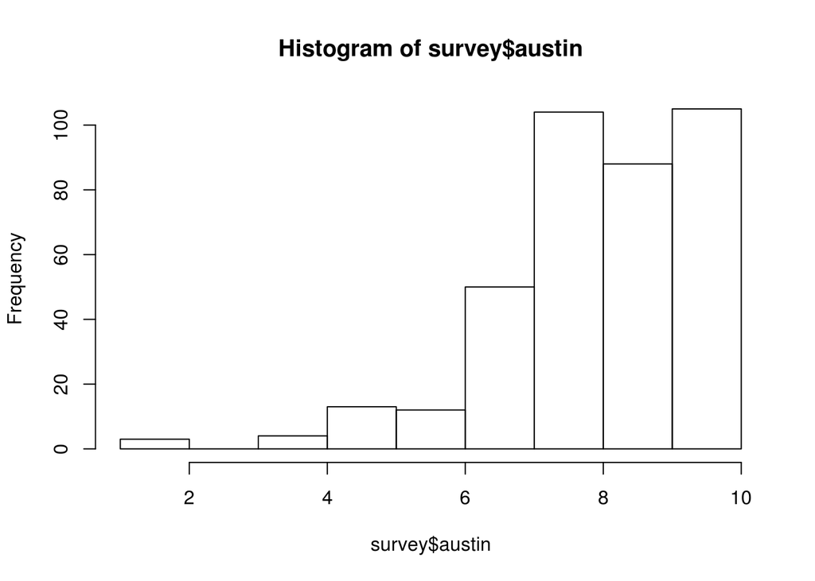

```r
hist(survey$austin)
```

```r
mean(survey$austin)
```

```
## [1] 8.390501
```

```r
sd(survey$austin)
```

```
## [1] 1.510725
```

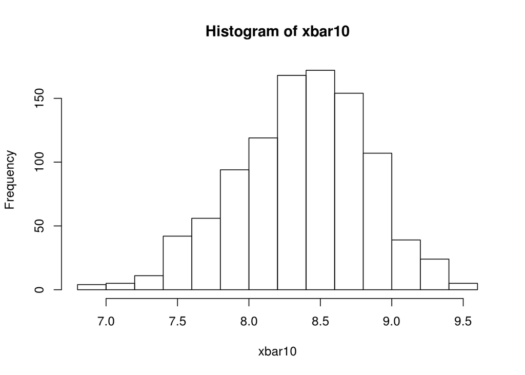

```r
xbar10 <-rep(NA, 1000)
for (i in 1:1000)
{x <-sample(survey$austin, size =10)
xbar10[i] <- mean(x)}
hist(xbar10)
```

```r
mean(xbar10)
```

```
## [1] 8.4187
```

```r
sd(xbar10)
```

```
## [1] 0.4614794
```

```r
sd(survey$austin)/sqrt(15)
```

```
## [1] 0.3900676
```

problem 1/1 point (graded) 1a. Create a histogram of the “austin” variable for the entire population of students that took the survey. Which best describes the shape of the distribution?

Left (Negative) Skewed correct Normal Right (Positive) Skewed Uniform Submit You have used 1 of 1 attempt Some problems have options such as save, reset, hints, or show answer. These options follow the Submit button.

Show Answer Correct (1/1 point) Review problem 1/1 point (graded) 1b. What is the population mean for the “austin” variable? (Round to 2 decimal places.)

8.39 correct 8.39 Submit You have used 1 of 1 attempt Some problems have options such as save, reset, hints, or show answer. These options follow the Submit button.

Show Answer Correct (1/1 point) Review problem 1/1 point (graded) 1c. What is the population standard deviation for the “austin” variable? (Report to 2 decimal places.)

1.51 correct 1.51 Submit You have used 1 of 1 attempt Some problems have options such as save, reset, hints, or show answer. These options follow the Submit button.

Show Answer Correct (1/1 point) Review 1d. Use the Central Limit Theorem to predict the mean and standard deviation of the sampling distribution of means for samples of size n=10 drawn from this population:

problem 1/1 point (graded) What is the expected mean? (Round to 2 decimal places.)

8.39 correct 8.39 Submit You have used 1 of 1 attempt Some problems have options such as save, reset, hints, or show answer. These options follow the Submit button.

Show Answer Correct (1/1 point) Review problem 0/1 point (graded) What is the expected standard deviation? (Round to 2 decimal places.)

1.51 incorrect.48 1.51 Submit You have used 1 of 1 attempt Some problems have options such as save, reset, hints, or show answer. These options follow the Submit button.

Show Answer Answers are displayed within the problem Review problem 1/1 point (graded) 1e. Simulate drawing 1,000 random samples of sample size n=10 from the “austin” distribution, then create a histogram of the sampling distribution and calculate it’s mean and standard deviation. How do these simulated values compare to the those predicted by the Central Limit Theorem?

The Central Limit Theorem is not correct. The values are close to one another. correct The values are not close. Submit

Question 2

A population of sunflower plants is described as having a monthly growth rate that follows a normal distribution with μ = 3.08 in and σ = 0.40 in.

Use this information to answer the following questions.

problem 1/1 point (graded) 2a. What is the probability that a randomly chosen sunflower plant grows more than 3.2 inches in a month? (Round to 3 decimal places.)

0.38 correct 0.38 Submit You have used 1 of 1 attempt Some problems have options such as save, reset, hints, or show answer. These options follow the Submit button.

Show Answer Correct (1/1 point) Review problem 1/1 point (graded) 2b. A middle-school science class grew 25 of these sunflowers. How many inches would they expect these flowers to have grown, on average, one month later? (Round to 2 decimal places.)

3.08 correct () Submit You have used 1 of 1 attempt Some problems have options such as save, reset, hints, or show answer. These options follow the Submit button.

Show Answer Correct (1/1 point) Review problem 0/1 point (graded) 2c. The middle school science teacher replicates her study with 25 new sunflowers every year. How much variability in inches should she expect in the average monthly growth of these samples? (Round to 2 decimal places.)

0.40 incorrect.08 () Submit You have used 1 of 1 attempt Some problems have options such as save, reset, hints, or show answer. These options follow the Submit button.

Show Answer Answers are displayed within the problem Review problem 1/1 point (graded) 2d. The science teacher notices that the average monthly growth of her 25 sunflowers has never exceeded 3.2 inches. What should she conclude?

About 38% of her samples should have an average growth of 3.2 inches or more, so something is wrong with her data. Her data suggests that the original growth parameters given for this sunflower population must be wrong. We wouldn’t expect to see an average monthly growth of 3.2 inches for a sample of 25 plants. Her data is probably fine. correct Submit You have used 1 of 1 attempt Some problems have options such as save, reset, hints, or show answer. These options follow the Submit button.

Show Answer Correct (1/1 point) Review problem 0/1 point (graded) 2e. What is the probability that her next sample of 25 sunflowers will grow an average of more than 2.9, but less than 3.2 inches, in a month? (Report as a proportion rounded to 3 decimal places.)

0.056 incorrect.921 () Submit

Question 3

A very large company has its headquarters in a 15-story downtown office building. The morning commute time for employees of this company is normally distributed with a mean of 28 minutes and a standard deviation of 11 minutes.

The company in the building next door samples 23 of its employees and finds that their mean commute time is 35.1 minutes. Is there evidence that their commute time is longer than the other company’s, or is this just random sampling error?

Use the Central Limit Theorem to determine if this sample mean is likely to be observed, assuming commute time is the same for both companies. problem 1/1 point (graded) 3a. What is the expected mean in minutes of the sampling distribution for samples of size n=23? (Report as a whole number)

28 correct () Submit You have used 1 of 1 attempt Some problems have options such as save, reset, hints, or show answer. These options follow the Submit button.

Show Answer Correct (1/1 point) Review problem 1/1 point (graded) 3b. What is the expected standard error of the sampling distribution for samples of n=23? (Round to 2 decimal places.)

2.29 correct () Submit You have used 1 of 1 attempt Some problems have options such as save, reset, hints, or show answer. These options follow the Submit button.

Show Answer Correct (1/1 point) Review problem 0/1 point (graded) 3c. What is the z-score for the neighboring company’s sample mean? (Round to 1 decimal place.)

0.7 incorrect3.1 () Submit You have used 1 of 1 attempt Some problems have options such as save, reset, hints, or show answer. These options follow the Submit button.

Show Answer Answers are displayed within the problem Review problem 1/1 point (graded) 3d. What is the probability of observing a sample mean this high (or higher), if the employees really do commute the same amount of time?

About 0.1 About 0.01 Less than 0.001 correct Submit You have used 1 of 1 attempt Some problems have options such as save, reset, hints, or show answer. These options follow the Submit button.

Show Answer Correct (1/1 point) Review problem 1/1 point (graded) 3e. What should we conclude about the sample mean of 35.1 minutes?

It is a sample mean that is likely be observed. It is a sample mean that is not likely to be observed. correct Submit You have used 1 of 1 attempt Some problems have options such as save, reset, hints, or show answer. These options follow the Submit button.

Show Answer Correct (1/1 point) Review problem 1/1 point (graded) 3f. What should we conclude about the commute time of the employees in the building next door?

The average commute time is probably the SAME as the large company next door (our original population). The difference in sample means is probably random sampling error. Their average commute time is probably NOT the same as the large company next door (our original population). correct Submit You have used 1 of 1 attempt Some problems have options such as save, reset, hints, or show answer. These options follow the Submit button.

Show Answer Correct (1/1 point) Review problem 1/1 point (graded) 3g. What must we assume about the 23 people that were sampled for our conclusion to be valid?

Their average commute time cannot exceed 28 minutes. They must all have the same type of job. They must be a representative sample of employees at the company. correct They must live no more than 20 miles from downtown, because that would increase commute time.

Question 4

Dixie Queen uses an automatic ice cream dispenser to fill pint-sized containers of ice cream. The company that makes the dispenser says the volume it dispenses into each container follows a normal distribution with σ= 1.5 ml.

The Dixie Queen manager randomly selected 15 ice cream pints and found that the average volume was 471.46 ml. She wants to know if her machine is performing as expected. problem 1/1 point (graded) 4a. What is the expected variability in sample means of size n=15? (Find the standard error and round to 3 decimal places.)

0.39 correct 0.39 Submit You have used 1 of 1 attempt Some problems have options such as save, reset, hints, or show answer. These options follow the Submit button.

Show Answer problem 0/1 point (graded) 4b. What is the margin of error, assuming 95% confidence? (Round to 3 decimal places and use this value in the following calculations.)

0.759 incorrect.759 0.022 Submit You have used 1 of 1 attempt Some problems have options such as save, reset, hints, or show answer. These options follow the Submit button.

Show Answer 4c. Find the 95% confidence interval for the mean volume for this sample of 15 randomly selected ice cream pint containers.

problem 1/1 point (graded) Lower Bound (Round to 1 decimal place.)

470.7 correct () Loading Submit You have used 1 of 1 attempt Some problems have options such as save, reset, hints, or show answer. These options follow the Submit button.

Show Answer Correct (1/1 point) Review problem 1/1 point (graded) Upper Bound (Round to 1 decimal place.)

472.2 correct () Submit You have used 1 of 1 attempt Some problems have options such as save, reset, hints, or show answer. These options follow the Submit button.

Show Answer Correct (1/1 point) Review problem 1/1 point (graded) 4d. A pint is equivalent to 473.20 ml. Do you think the dispenser is working as reported?

Yes No correct